```python
from sklearn import cluster as ct
from sklearn import metrics as mt
import pandas as pd

import warnings
warnings.filterwarnings("ignore") # Ignorar Avisos
```

# Propagação por Afinidade para dataset 'mall_customers'

```python
import numpy as np
import matplotlib.pyplot as plt
from sklearn.cluster import AffinityPropagation
from sklearn.preprocessing import StandardScaler
import seaborn as sns
from itertools import cycle # itertools: Funções que criam iteradores para laços eficientes
```

```python
df1 = pd.read_csv('D:\A - PUC\Mineração\Dados\shopping.csv')
df2 = df1[['Annual Income (k$)','Spending Score (1-100)']]
df2.head(3)
```

|  | Annual Income (k$) | Spending Score (1-100) |
| --- | --- | --- |
| 0 | 15 | 39 |
| 1 | 15 | 81 |
| 2 | 16 | 6 |

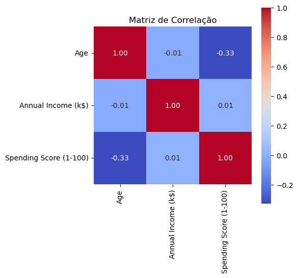

```python
'''A visualização da Matriz de Correlação ajuda a entender como os recursos estão correlacionados entre si. '''
df1 = df1.drop('CustomerID' , axis = 1)
correl_matriz = df1.corr(numeric_only=True)
plt.figure(figsize=(5, 5))
# annot=True: escreve os valores nos quadrados. cmap="coolwarm" = cores
# fmt=".2f": casas decimais. square=True: formato quadrado.
sns.heatmap(correl_matriz , annot=True , cmap="coolwarm", fmt=".2f" , square=True)
plt.title("Matriz de Correlação")
plt.show()
```

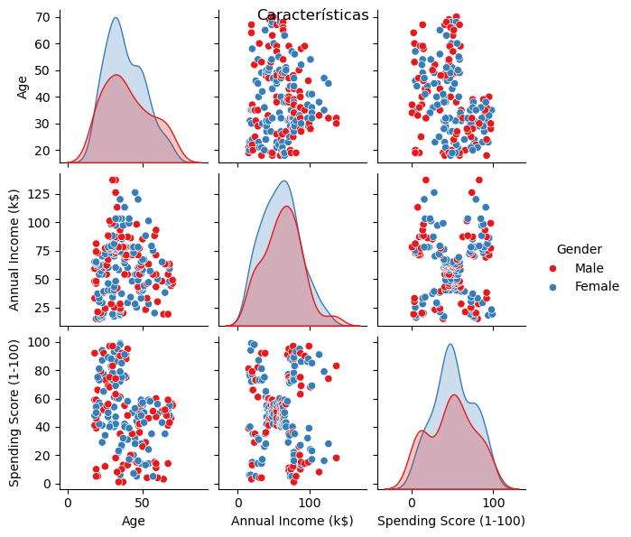

```python
''' Gráficos de Dispersão '''
sns.pairplot(df1, palette = "Set1", hue = "Gender", height = 2)
plt.suptitle("Características")
plt.show()
```

# Parâmetros do 'AffinityPropagation'

### dampingfloat (padrão=0,5): O fator de amortecimento no intervalo [0,5 ; 1,0] é a extensão em que o valor

### atual é mantido em relação aos valores de entrada (ponderação 1 - amortecimento).

### Isso é feito para evitar oscilações numéricas ao atualizar esses valores (mensagens).

### max_iterint (padrão=200): Número máximo de iterações.

### convergence_iterint (padrão=15): Número de iterações sem alteração no número de clusters estimados que

### interrompe a convergência.

### copybool (padrão=True): Fazer uma cópia dos dados de entrada.

### preferencearray-like de formato (n_samples,) ou float (padrão=None): Preferências para cada ponto - pontos

### com valores maiores de preferências têm maior probabilidade de serem escolhidos como exemplares.

### O número de exemplares, ou seja, de clusters, é influenciado pelo valor das preferências de entrada.

### Se as preferências não forem passadas como argumentos, elas serão definidas como a mediana das similaridades

### affinity{‘euclidean’, ‘precomputed’} (default=’euclidean’): Qual afinidade usar. No momento, ‘precomputed’

### e euclidean são suportados. ‘euclidean’ usa a distância euclidiana ao quadrado negativo entre os pontos.

### verbosebool (default=False)

### random_stateint, instância

### RandomState ou None (default=None): Gerador de números pseudoaleatórios para controlar o estado inicial.

### Use um int para resultados reproduzíveis entre chamadas de função.

```python
# Standard Scaler normaliza os dados para a propagação do Affinity.
escala = StandardScaler()
X_std = escala.fit_transform(df2)

af = AffinityPropagation(max_iter = 100, random_state = 12).fit(X_std)

labels = af.labels_
```

```python
silhouette_score = mt.silhouette_score(X_std, labels)
print(f"Silhouette Score: {silhouette_score:.5f}")
```

```
Silhouette Score: 0.43210
```

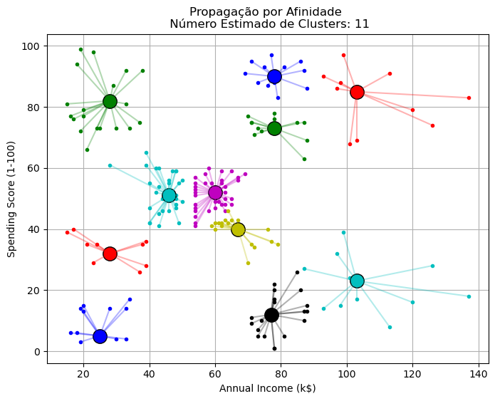

```python
plt.figure(figsize=(8, 6))
colors = cycle('bgrcmyk')

n_clusters_ = len(af.cluster_centers_indices_)
centers_indices = af.cluster_centers_indices_

for k, col in zip(range(n_clusters_), colors):
    class_members = labels == k
    cluster_center = df2.iloc[centers_indices[k]]

    plt.plot(df2.iloc[class_members, 0], df2.iloc[class_members, 1], col + '.')
    plt.plot(cluster_center[0], cluster_center[1], 'o',
             markerfacecolor=col, markeredgecolor='k', markersize=14)

    for x in df2.iloc[class_members].values:
        plt.plot([cluster_center[0], x[0]], [cluster_center[1], x[1]], col, alpha=0.3)

plt.title(f'Propagação por Afinidade \n Número Estimado de Clusters: {n_clusters_}')
plt.xlabel('Annual Income (k$)')
plt.ylabel('Spending Score (1-100)')
plt.grid(True)
plt.show()
```

# Agrupamento po Afinidade de Propagação com DADOS ALEATÓRIOS

### A função make_blobs do sklearn.datasets gera um conjunto de pontos n-dimensional, em que cada ponto

### pertence a um dos k clusters.

### A classe AffinityPropagation do sklearn.cluster faz o agrupamento nos dados.

```python
from sklearn.datasets import make_blobs

df4, labels_true = make_blobs(n_samples=500, cluster_std = 1, random_state = 0)

af = AffinityPropagation(preference = -30 , random_state = 0).fit(df4)
cluster_centers_indices = af.cluster_centers_indices_
labels = af.labels_

n_clusters_ = len(cluster_centers_indices)

print("Número estimado de clusters: %d" % n_clusters_)
print("Coeficiente de Silhueta: %0.3f" % mt.silhouette_score(df4, labels, metric="sqeuclidean"))
```

```
Número estimado de clusters: 11
Coeficiente de Silhueta: 0.478
```

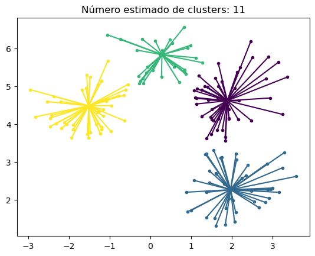

```python
plt.close("all")
plt.figure(1)
plt.clf()

colors = plt.cycler("color", plt.cm.viridis(np.linspace(0, 1, 4)))

for k, col in zip(range(n_clusters_), colors):
    class_members = labels == k
    cluster_center = df4[cluster_centers_indices[k]]
    plt.scatter(
        df4[class_members, 0], df4[class_members, 1], color=col["color"], marker="."
    )
    plt.scatter(
        cluster_center[0], cluster_center[1], s=14, color=col["color"], marker="o"
    )
    for x in df4[class_members]:
        plt.plot(
            [cluster_center[0], x[0]], [cluster_center[1], x[1]], color=col["color"]
        )

plt.title("Número estimado de clusters: %d" % n_clusters_)
plt.show()
```

# Mostra a influência dos valores de preference em relação à silhoutte.

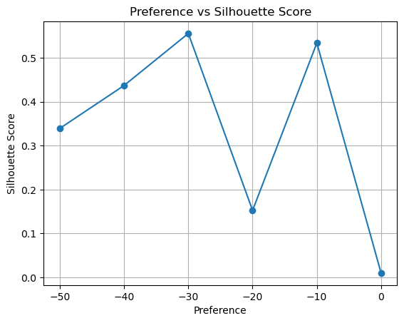

```python
Preference = [-50, -40, -30, -20, -10 , 0]
silhouette_scores = []

for preference in Preference:
    model = AffinityPropagation(preference=preference, random_state=42)
    model.fit(X_std)

    # Evaluate only if more than one cluster is found
    if len(np.unique(model.labels_)) > 1:
        score = mt.silhouette_score(X_std, model.labels_)
        silhouette_scores.append(score)
    else:
        silhouette_scores.append(np.nan)

plt.plot(Preference, silhouette_scores, marker='o')
plt.title('Preference vs Silhouette Score')
plt.xlabel('Preference')
plt.ylabel('Silhouette Score')
plt.grid()
plt.show()
```